# Exercices in linear models and experimental design

Ana

30/5/2019

## Introduction

These exercises describe experimental situations that have been studied using some omics technology like microarrays.

## Expression profiling by array

This case study is based on a paer published in https://www.ncbi.nlm.nih.gov/geo/query/acc.cgi?acc=GSE113664 whose data are available in GEO as series GSE113664 series.

UHRF1 is a major regulator of epigenetic mechanism and is overexpressed in various human malignancies. In this study, we examined the involvement of UHRF1 in aberrant DNA methylation in colorectal cancer (CRC). In CRC cells, transient UHRF1 knockdown rapidly induced DNA demethylation across entire genomic regions, including CpG islands, gene bodies and repetitive elements. Nonetheless, UHRF1 depletion only minimally reversed CpG island hypermethylation-associated gene silencing. However, the combination of UHRF1 depletion and histone deacetylase (HDAC) inhibition synergistically reactivated the silenced genes and strongly suppressed CRC cell proliferation. Our results suggest that (i) maintenance of DNA methylation in CRC cells is highly dependent on UHRF1; (ii) UHRF1 depletion rapidly induces DNA demethylation, though it is insufficient to fully reactivate the silenced genes; and (iii) dual targeting of UHRF1 and HDAC may be an effective new therapeutic strategy.

```r
require (limma)
targetsLocation<- 'sample.txt'
targets <- read.csv('sample.txt', sep = '')

targets
```

```
##   Identifier         Group    Type                  Drug
## 1 GSM3110847  RKO_siCONT_r control                  mock
## 2 GSM3110848  RKO_siCONT_r control                  mock
## 3 GSM3110849   RKO_siUHRF1   UHRF1                  mock
## 4 GSM3110850   RKO_siUHRF1   UHRF1                  mock
## 5 GSM3110851 RKO_siCONT_pr control        Trichostatin_A
## 6 GSM3110852 RKO_siCONT_pr control        Trichostatin_A
## 7 GSM3110853 RKO_siCONT_pt   UHRF1        Trichostatin_A
## 8 GSM3110854 RKO_siCONT_pt   UHRF1        Trichostatin_A
## 9 GSM3118962     RKO_w_AZA    none 5-aza-2-deoxycytidine
```

```r
dataLocation<- 'GSE113664_series_matrix.txt'
dataMatrix <- read.delim("GSE113664_series_matrix.txt", row.names = 1)
colnames(dataMatrix)==rownames(targets)
```

```
## [1] FALSE FALSE FALSE FALSE FALSE FALSE FALSE FALSE FALSE
```

```r
head(dataMatrix)
```

```
##   GSM3110847 GSM3110848 GSM3110849 GSM3110850 GSM3110851 GSM3110852
## 1   31400.00   22100.00   23000.00   24700.00   36900.00   29600.00
## 2       3.65       4.04       3.96       3.65       3.56       4.09
## 3       3.66       4.05       3.97       3.65       3.56       4.09
## 4    4010.00    3910.00    4900.00    4630.00    3370.00    3590.00
## 5       3.67       4.06       3.98       5.34       3.56       4.08
## 6       3.68       4.07       3.98       3.63       3.96       4.08
##   GSM3110853 GSM3110854 GSM3118962
## 1   31200.00   30000.00   29100.00
## 2       3.86       3.87       7.78
## 3       3.87       3.87       7.82
## 4    3160.00    3700.00    6060.00
## 5       3.86       3.85       7.88
## 6       3.86       3.84       7.90
```

```r
design<-matrix(
  c(1,1,0,0,0,0,0,0,0,
    0,0,1,1,0,0,0,0,0,
    0,0,0,0,1,1,0,0,0,
    0,0,0,0,0,0,1,1,0,
    0,0,0,0,0,0,0,0,1),
  nrow=9,byrow=F)
design2 <-model.matrix(~ 0+targets$Group)
colnames(design)<- colnames(design2)<-c("A", "B", "C" , "D", "E")
rownames(design) <- rownames(design2)<- targets$SampleIDs
print(design); print(design2)
```

```
##       A B C D E
##  [1,] 1 0 0 0 0
##  [2,] 1 0 0 0 0
##  [3,] 0 1 0 0 0
##  [4,] 0 1 0 0 0
##  [5,] 0 0 1 0 0
##  [6,] 0 0 1 0 0
##  [7,] 0 0 0 1 0
##  [8,] 0 0 0 1 0
##  [9,] 0 0 0 0 1
```

```
##       A B C D E
##  [1,] 0 0 1 0 0
##  [2,] 0 0 1 0 0
##  [3,] 0 0 0 1 0
##  [4,] 0 0 0 1 0
##  [5,] 1 0 0 0 0
##  [6,] 1 0 0 0 0
##  [7,] 0 1 0 0 0
##  [8,] 0 1 0 0 0
##  [9,] 0 0 0 0 1
## attr(,"assign")
## [1] 1 1 1 1 1
## attr(,"contrasts")
## attr(,"contrasts")$`targets$Group`
## [1] "contr.treatment"
```

```r
cont.matrix <- makeContrasts (
  AvsB = B-A,
  AvsC = C-A,
  AvsD = D-B,
  AvsE = E-A,
  BvsC = C-B,
  BvsD = D-B,
  BvsE = E-B,
  CvsD = D-C,
  CvsE = E-C,
  DvsE = E-D,
  levels=design)
design
```

```
##       A B C D E
##  [1,] 1 0 0 0 0
##  [2,] 1 0 0 0 0
##  [3,] 0 1 0 0 0
##  [4,] 0 1 0 0 0
##  [5,] 0 0 1 0 0
##  [6,] 0 0 1 0 0
##  [7,] 0 0 0 1 0
##  [8,] 0 0 0 1 0
##  [9,] 0 0 0 0 1
```

```r
require(limma)
fit<-lmFit(dataMatrix, design)
fit.main<-contrasts.fit(fit, cont.matrix)
fit.main<-eBayes(fit.main)
```

```r
topTab_AvsB <- topTable (fit.main, number=nrow(fit.main), coef="AvsB", adjust="fdr"); head(topTab_AvsB)
```

```
##          logFC    AveExpr         t      P.Value  adj.P.Val        B
## 31585   170.00 1645.55556  50.38760 2.695845e-07 0.01697735 1.186659
## 1518     58.95   25.56667  30.63695 2.442273e-06 0.03927424 1.086894
## 5679     98.85   44.60667  28.47878 3.373384e-06 0.03927424 1.062645
## 52889  1245.00 7618.88889  26.56909 4.584233e-06 0.03927424 1.036365
## 52985 -1467.50 2115.11111 -26.51391 4.626521e-06 0.03927424 1.035525
## 6025     68.50  184.11111  26.33376 4.767959e-06 0.03927424 1.032748
```

```r
topTab_AvsC <- topTable (fit.main, number=nrow(fit.main), coef="AvsC", adjust="fdr"); head(topTab_AvsC)
```

```
##          logFC    AveExpr         t      P.Value   adj.P.Val        B
## 29441   -62.35   125.1333 -75.39578 4.510971e-08 0.001460921 1.219973
## 22691  -874.00   818.0000 -69.58483 6.439277e-08 0.001460921 1.215266
## 43187  -884.50   813.2222 -68.37723 6.959419e-08 0.001460921 1.214136
## 32848 -4750.00 15100.0000 -63.30538 9.796606e-08 0.001489923 1.208669
## 28138  -877.50   813.8889 -57.18697 1.537789e-07 0.001489923 1.200067
## 48675   763.00   812.7778  56.38823 1.636784e-07 0.001489923 1.198736
```

```r
topTab_AvsD  <- topTable (fit.main, number=nrow(fit.main) , coef="AvsD", adjust="fdr");head(topTab_AvsD)
```

```
##         logFC   AveExpr         t      P.Value    adj.P.Val        B
## 7643   851.80 1012.5444 174.20263 1.095721e-09 6.900412e-05 1.242085
## 25998  168.90  262.8433 116.41861 6.558491e-09 1.586924e-04 1.235749
## 58214   57.25  162.0000 112.75203 7.559660e-09 1.586924e-04 1.234993
## 40294   70.63  233.0000  93.93494 1.700222e-08 2.676829e-04 1.229628
## 29441  -71.55  125.1333 -86.52074 2.449024e-08 3.084595e-04 1.226499
## 48675 1054.50  812.7778  77.93105 3.895184e-08 3.780373e-04 1.221707
```

```r
topTab_AvsE  <- topTable (fit.main, number=nrow(fit.main) , coef="AvsE", adjust="fdr");head(topTab_AvsE)
```

```
##            logFC    AveExpr         t      P.Value    adj.P.Val         B
## 61105 412993.765 45893.3444 164172.49 6.797167e-23 4.280584e-18 0.4254620
## 47888 117993.720 13115.2667  53822.89 9.617624e-21 3.028397e-16 0.4254619
## 34264   9056.070  1010.2522  12572.08 6.131745e-18 9.053175e-14 0.4254613
## 24649  11097.005  1242.2956  12526.37 6.231733e-18 9.053175e-14 0.4254613
## 57792   5996.835   669.5067  12130.15 7.187797e-18 9.053175e-14 0.4254613
## 46883 125976.650 14056.4333  11498.39 9.114824e-18 9.566919e-14 0.4254612
```

```r
topTab_BvsC <- topTable (fit.main, number=nrow(fit.main) , coef="BvsC", adjust="fdr"); head(topTab_BvsC)
```

```
##          logFC    AveExpr         t      P.Value    adj.P.Val        B
## 29441   -63.35   125.1333 -76.60502 4.203437e-08 0.0007429580 1.220822
## 10227  -396.60   230.7889 -76.35911 4.263845e-08 0.0007429580 1.220652
## 31585  -255.00  1645.5556 -75.58140 4.462017e-08 0.0007429580 1.220106
## 32848 -5600.00 15100.0000 -74.63371 4.718991e-08 0.0007429580 1.219418
## 43187  -874.50   813.2222 -67.60417 7.319529e-08 0.0008102444 1.213381
## 22691  -839.00   818.0000 -66.79825 7.719554e-08 0.0008102444 1.212565
```

```r
topTab_BvsE <- topTable (fit.main, number=nrow(fit.main) , coef="BvsE", adjust="fdr"); head(topTab_BvsE)
```

```
##            logFC    AveExpr         t      P.Value    adj.P.Val         B
## 61105 412994.155 45893.3444 164172.64 6.797138e-23 4.280566e-18 0.4254620
## 47888 117996.115 13115.2667  53823.98 9.616757e-21 3.028124e-16 0.4254619
## 34264   9056.190  1010.2522  12572.25 6.131385e-18 9.053175e-14 0.4254613
## 24649  11097.090  1242.2956  12526.47 6.231521e-18 9.053175e-14 0.4254613
## 57792   5996.835   669.5067  12130.15 7.187797e-18 9.053175e-14 0.4254613
## 46883 125886.000 14056.4333  11490.11 9.144006e-18 9.597549e-14 0.4254612
```

```r
topTab_BvsD <- topTable (fit.main, number=nrow(fit.main) , coef="BvsD", adjust="fdr"); head(topTab_BvsD)
```

```
##         logFC   AveExpr         t      P.Value    adj.P.Val        B
## 7643   851.80 1012.5444 174.20263 1.095721e-09 6.900412e-05 1.242085
## 25998  168.90  262.8433 116.41861 6.558491e-09 1.586924e-04 1.235749
## 58214   57.25  162.0000 112.75203 7.559660e-09 1.586924e-04 1.234993
## 40294   70.63  233.0000  93.93494 1.700222e-08 2.676829e-04 1.229628
## 29441  -71.55  125.1333 -86.52074 2.449024e-08 3.084595e-04 1.226499
## 48675 1054.50  812.7778  77.93105 3.895184e-08 3.780373e-04 1.221707
```

```r
topTab_CvsD <- topTable (fit.main, number=nrow(fit.main) , coef="BvsC", adjust="fdr"); head(topTab_CvsD)
```

```
##          logFC    AveExpr         t      P.Value    adj.P.Val        B
## 29441   -63.35   125.1333 -76.60502 4.203437e-08 0.0007429580 1.220822
## 10227  -396.60   230.7889 -76.35911 4.263845e-08 0.0007429580 1.220652
## 31585  -255.00  1645.5556 -75.58140 4.462017e-08 0.0007429580 1.220106
## 32848 -5600.00 15100.0000 -74.63371 4.718991e-08 0.0007429580 1.219418
## 43187  -874.50   813.2222 -67.60417 7.319529e-08 0.0008102444 1.213381
## 22691  -839.00   818.0000 -66.79825 7.719554e-08 0.0008102444 1.212565
```

```r
topTab_CvsE <- topTable (fit.main, number=nrow(fit.main) , coef="CvsE", adjust="fdr"); head(topTab_CvsE)
```

```
##           logFC    AveExpr         t      P.Value    adj.P.Val         B
## 61105 412995.54 45893.3444 164173.19 6.797037e-23 4.280502e-18 0.4254620
## 47888 117995.43 13115.2667  53823.67 9.617005e-21 3.028202e-16 0.4254619
## 34264   9056.15  1010.2522  12572.19 6.131505e-18 9.053342e-14 0.4254613
## 24649  11096.98  1242.2956  12526.34 6.231808e-18 9.053342e-14 0.4254613
## 57792   5996.81   669.5067  12130.10 7.187930e-18 9.053342e-14 0.4254613
## 46883 125973.80 14056.4333  11498.13 9.115740e-18 9.567881e-14 0.4254612
```

```r
topTab_DvsE <- topTable (fit.main, number=nrow(fit.main) , coef="DvsE", adjust="fdr"); head(topTab_DvsE)
```

```
##            logFC    AveExpr         t      P.Value    adj.P.Val         B
## 61105 412996.490 45893.3444 164173.57 6.796968e-23 4.280458e-18 0.4254620
## 47888 117996.035 13115.2667  53823.95 9.616786e-21 3.028134e-16 0.4254619
## 34264   9055.455  1010.2522  12571.23 6.133595e-18 9.053811e-14 0.4254613
## 24649  11068.600  1242.2956  12494.31 6.303063e-18 9.053811e-14 0.4254613
## 57792   5996.740   669.5067  12129.96 7.188303e-18 9.053811e-14 0.4254613
## 46883 125909.600 14056.4333  11492.27 9.136398e-18 9.589563e-14 0.4254612
```

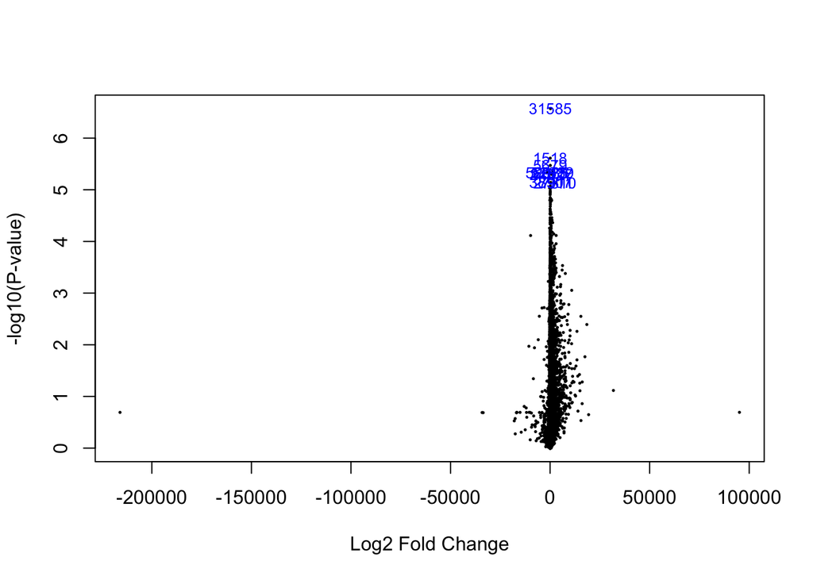

```r
volcanoplot(fit.main, coef="AvsB", highlight=10)
```

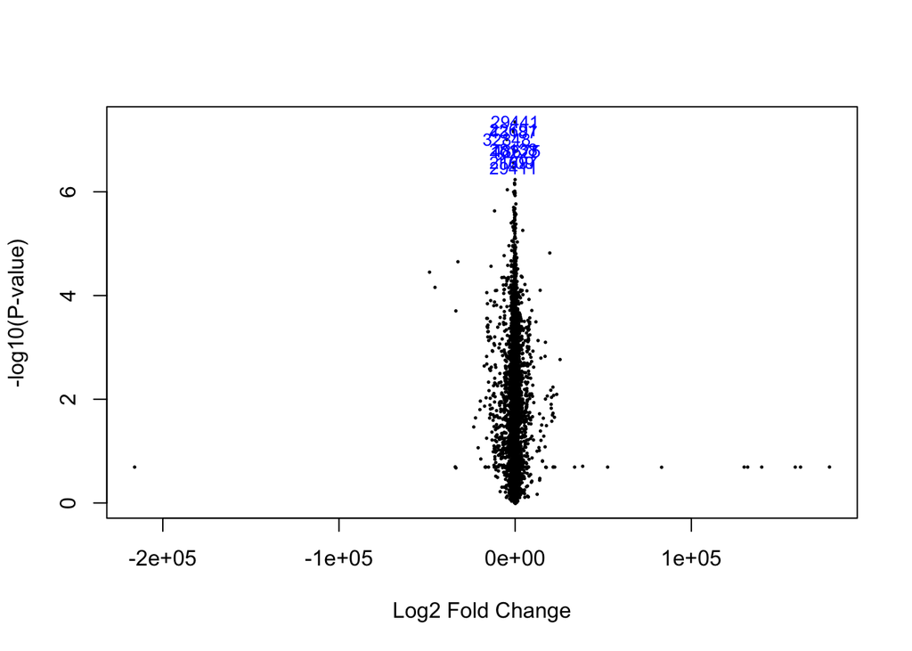

```r
volcanoplot(fit.main, coef="AvsC", highlight=10)
```

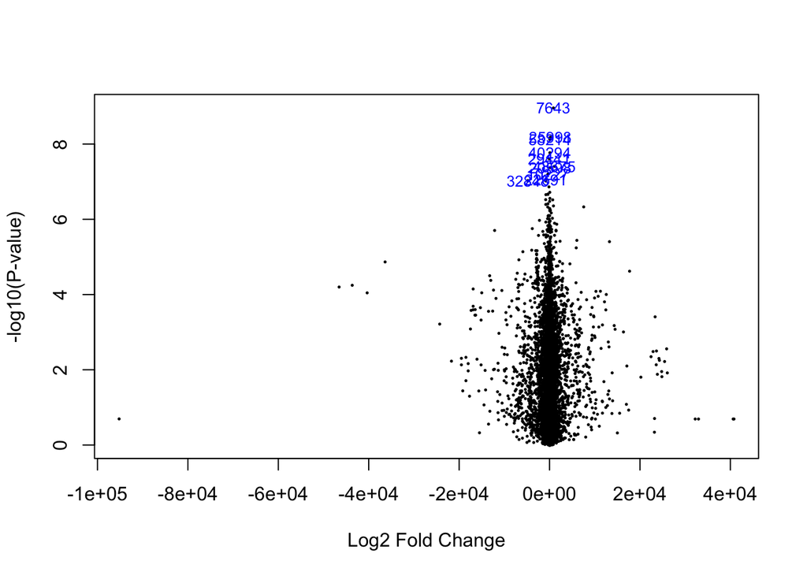

```r
volcanoplot(fit.main, coef="AvsD", highlight=10)
```

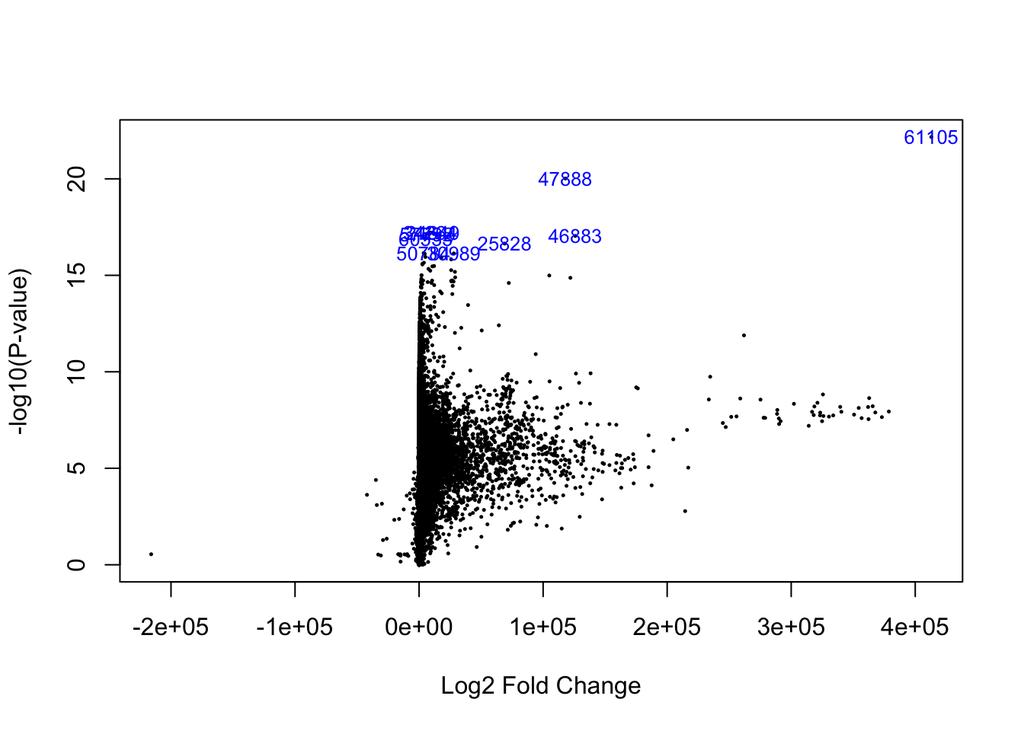

```r
volcanoplot(fit.main, coef="AvsE", highlight=10)
```

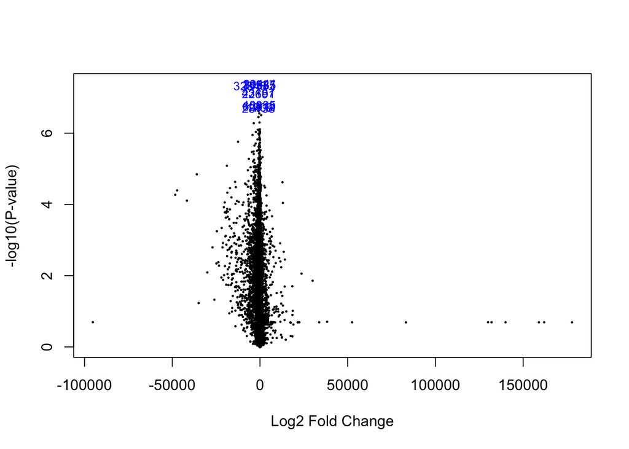

```r
volcanoplot(fit.main, coef="BvsC", highlight=10)
```

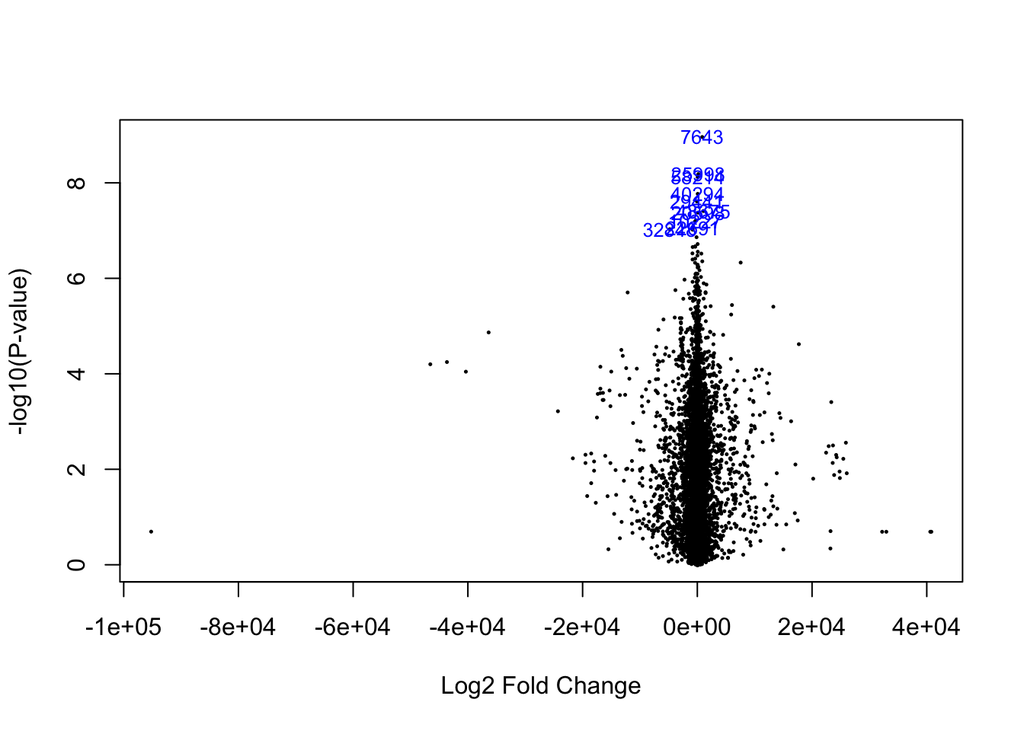

```r
volcanoplot(fit.main, coef="BvsD", highlight=10)
```

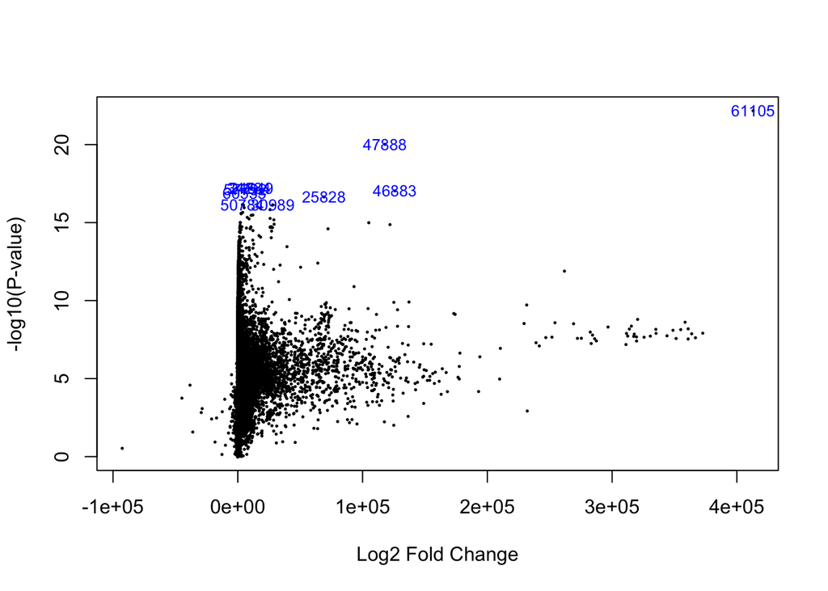

```r
volcanoplot(fit.main, coef="BvsE", highlight=10)
```

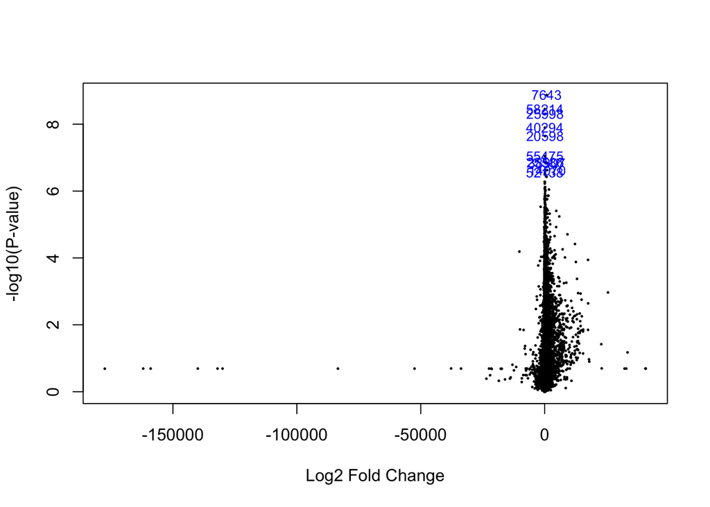

```r
volcanoplot(fit.main, coef="CvsD", highlight=10)
```

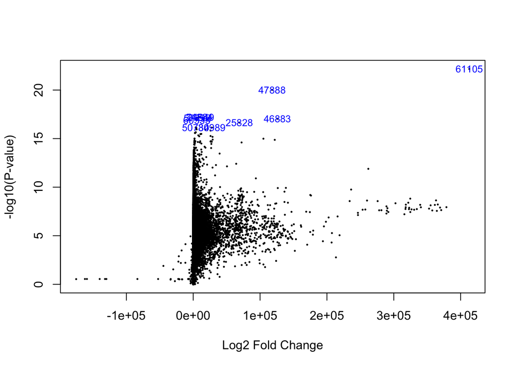

```r
volcanoplot(fit.main, coef="CvsE", highlight=10)
```

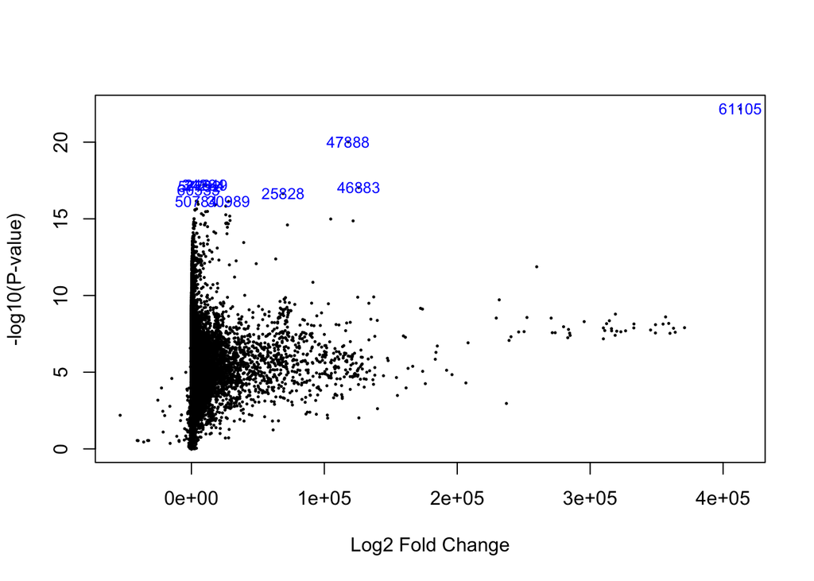

```r
volcanoplot(fit.main, coef="DvsE", highlight=10)
```

```r
if (!require(GEOquery)) {
  BiocManager::install("GEOquery")
}
```

```
## Setting options('download.file.method.GEOquery'='auto')
```

```
## Setting options('GEOquery.inmemory.gpl'=FALSE)
```

```r
require(GEOquery)
gse <- getGEO("GSE27174")
```

```
## Found 1 file(s)
```

```
## GSE27174_series_matrix.txt.gz
```

```
## File stored at:
```

```
## /var/folders/q0/s89vbh5j4cbc35v98j66hkyh0000gn/T//RtmpPoESYI/GPL6246.soft
```

```r
class(gse)
```

```
## [1] "list"
```

```r
names(gse)
```

```
## [1] "GSE27174_series_matrix.txt.gz"
```

```r
gse[[1]]
```

```
## ExpressionSet (storageMode: lockedEnvironment)
## assayData: 35557 features, 8 samples
##   element names: exprs
## protocolData: none
## phenoData
##   sampleNames: GSM671653 GSM671654 ... GSM671660 (8 total)
##   varLabels: title geo_accession ... strain:ch1 (40 total)
##   varMetadata: labelDescription
## featureData
##   featureNames: 10338001 10338002 ... 10608724 (35557 total)
##   fvarLabels: ID GB_LIST ... category (12 total)
##   fvarMetadata: Column Description labelDescription
## experimentData: use 'experimentData(object)'
##   pubMedIds: 21725324
## Annotation: GPL6246
```

```r
esetFromGEO <- gse[[1]]
```